# Lección 2

por Manuel Villalobos

10/10/2017

# Análisis de expresión diferencial

Ahora veremos cómo se realiza un análisis de expresión diferencial, para esto usaremos la tabla de datos de un experimento que realizó el Dr. Sergio Campos de LANGEBIO. En este trabajo se pretendía evaluar la respuesta transcripcional de la levadura Saccharomyces cerevisiae a la carencia de nitrógeno y además se deseaba saber si el factor de transcripción Ste12 tiene un papel relevante en dicha respuesta transcripcional. Con este fin se ideo un experimento de RNA-seq tanto en un medio rico como carente de toda fuente de nitrógeno, usando a la cepa silvestre de S. cerevisiae y a la mutante nula del factor de transcripción.

### Comenzaremos viendo como instalar los programas que necesitamos

```r
#instalando paqueterias de bioconductor
#source("https://bioconductor.org/biocLite.R")
#biocLite("edgeR")
#biocLite("limma")


#necesitamos cargar edgeR y limma, para eso usamos la funsión library
library(edgeR)
library(limma)
```

Para comenzar a trabajar con nuestros datos de expresión debemos posicionarnos en el directorio donde esta nuestra tabla de datos, para posteriormente cargar la tabla en R.

Llamaremos a nuestra tabla y comenzaremos a manipularla

```r
setwd("~/Desktop/Curso_queretaro2017/")

#Podemos saber que archivos están en esta dirección usando el siguiente comando:

list.files()
```

```
##  [1] "~$troducción a R.docx"        "1.introR.html"
##  [3] "1.introR.R"                   "1.introR.Rmd"
##  [5] "2.expresion_dif.R"            "2.expresion_diferencial.html"
##  [7] "2.expresion_diferencial.R"    "2.expresion_diferencial.Rmd"
##  [9] "3.graficos.Rmd"               "Curso"
## [11] "Curso.zip"                    "hiseq_info.txt"
## [13] "histograma_revistas.pdf"      "Introducción a R.docx"
## [15] "ko_sc"                        "ko_slad"
## [17] "resultados"                   "Saccharomyces.txt"
## [19] "tabla.txt"
```

```r
#Para crear un archivo donde se almacenarán los resultados del análisis:
outpath = "~/Desktop/Curso_queretaro2017/resultados/"


dir.create(outpath, showWarnings=FALSE)

#aquí llamaremos a nuestra tabla de datos y la guardaremos en una variable dentro de R
counts = read.table("Saccharomyces.txt", header=TRUE, row.names = 1, sep="\t", comment.char="")

#Podemos saber cómo luce nuestra tabla cargada y que dimenciones tiene este objeto.
head(counts)
```

```
##         wt_sc_1 wt_sc_2 wt_sc_3 st_sc_1  st_sc_2 st_sc_3 wt_sl_1 wt_sl_2
## YHR055C       0       0       0       0    0.000       0       0       0
## YPR161C    1061    1375    1321    1189 1285.000    1334    1158    1409
## YOL138C     552     694     694     589  616.072     671    1581    1871
## YDR395W    2691    3331    3741    3310 3281.000    3473    1403    1649
## YGR129W     352     513     350     444  418.000     319     339     388
## YPR165W    2862    3900    3101    3749 3763.000    3274    3377    3899
##          wt_sl_3 st_sl_1 st_sl_2 st_sl_3
## YHR055C  354.525     0.0     0.0     198
## YPR161C 1070.000  1300.0  1379.0    1444
## YOL138C 1411.000  1665.4  1619.2    1951
## YDR395W 1297.000  1471.0  1651.0    1975
## YGR129W  266.000   381.0   334.0     424
## YPR165W 2926.000  3797.0  3533.0    3825
```

```r
dim(counts)
```

```
## [1] 6713   12
```

Algo que regularmente queremos hacer al iniciar un análisis de expresión génica, es filtrar los datos por la cantidad mínima de lecturas asociadas a cada gen, a fin de no tener muchos genes con muy baja expresión y que estos nos causen ruido en el análisis.

A manera de ejemplo, aquí les presento un filtrado usando las siguientes instrucciones

```r
#genes que tienen menos de 2 reads y en la suma de todas las filas da menos de 10 lecturas se elimnarán.

counts = counts[rowSums(cpm(counts) >= 2) >=10,]

#aquí vemos el uso del comando cpm y nos ayuda a tener los datos de expresión en cuentas por millón.

#despues de aplicar este filtro, nuestra tabla ha cambiado y podemos volver a evaluarla
head(counts)
```

```
##         wt_sc_1 wt_sc_2 wt_sc_3 st_sc_1  st_sc_2 st_sc_3 wt_sl_1 wt_sl_2
## YPR161C    1061    1375    1321    1189 1285.000    1334    1158    1409
## YOL138C     552     694     694     589  616.072     671    1581    1871
## YDR395W    2691    3331    3741    3310 3281.000    3473    1403    1649
## YGR129W     352     513     350     444  418.000     319     339     388
## YPR165W    2862    3900    3101    3749 3763.000    3274    3377    3899
## YPR098C     305     539     430     474  530.000     464    1429    1720
##         wt_sl_3 st_sl_1 st_sl_2 st_sl_3
## YPR161C    1070  1300.0  1379.0    1444
## YOL138C    1411  1665.4  1619.2    1951
## YDR395W    1297  1471.0  1651.0    1975
## YGR129W     266   381.0   334.0     424
## YPR165W    2926  3797.0  3533.0    3825
## YPR098C    1224  1635.0  1674.0    1859
```

```r
dim(counts)
```

```
## [1] 5831   12
```

```r
#si queremos visualizar únicamente los nombres de las columnas que componen a nuestra tabla.

colnames(counts)
```

```
##  [1] "wt_sc_1" "wt_sc_2" "wt_sc_3" "st_sc_1" "st_sc_2" "st_sc_3" "wt_sl_1"
##  [8] "wt_sl_2" "wt_sl_3" "st_sl_1" "st_sl_2" "st_sl_3"
```

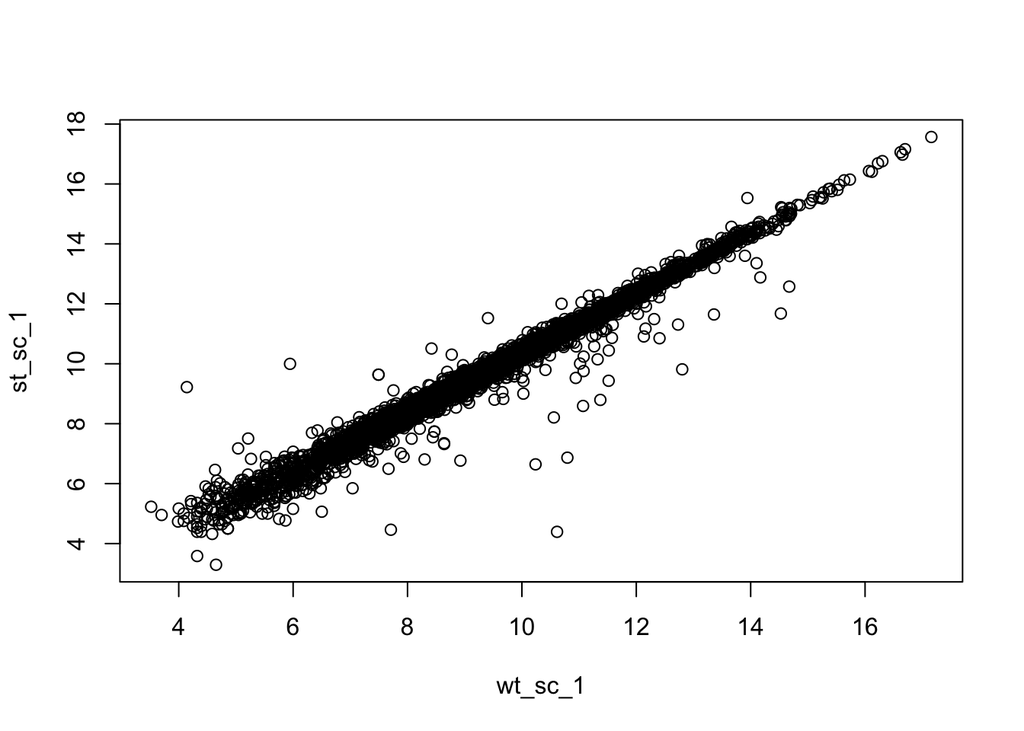

```r
#además teniendo los datos precargados, podemos visualizarlos en alguna gráfica como lo hemos visto antes

plot(log2(counts[,c("wt_sc_1", "st_sc_1")])) #aquí estamos comparando únicamente dos librerías, ustedes puedes probar otras.
```

```r
#lm(counts[,"wt_sc_1"] ~ counts[,"st_sc_3"] ) #regresión lineal.
```

## Ejercicio

### ¿Recuerdan cómo pedir específicamente algunas columnas?

Ahora comenzaremos a usar funciones de edgeR, este programa nos ayudará a determinar los genes diferencialmente expresados.

*Si desean conocer más acerca de este programa pueden consultar el manual desde R, usando la siguiente instrucción.

edgeRUsersGuide()

Debemos darle formato a nuestra tabla para que edgeR pueda funcionar sobre ella.

```r
#esto es para declarar los grupos que usaremos en el objeto DGEList (objeto de edgeR)
grp = sub("..$", "", colnames(counts))


#vean el objeto
grp
```

```
##  [1] "wt_sc" "wt_sc" "wt_sc" "st_sc" "st_sc" "st_sc" "wt_sl" "wt_sl"
##  [9] "wt_sl" "st_sl" "st_sl" "st_sl"
```

```r
#haciendo el objeto DGEList
dge = DGEList(counts=counts, group=grp)

dge
```

```
## An object of class "DGEList"
## $counts
##         wt_sc_1 wt_sc_2 wt_sc_3 st_sc_1  st_sc_2 st_sc_3 wt_sl_1 wt_sl_2
## YPR161C    1061    1375    1321    1189 1285.000    1334    1158    1409
## YOL138C     552     694     694     589  616.072     671    1581    1871
## YDR395W    2691    3331    3741    3310 3281.000    3473    1403    1649
## YGR129W     352     513     350     444  418.000     319     339     388
## YPR165W    2862    3900    3101    3749 3763.000    3274    3377    3899
##         wt_sl_3 st_sl_1 st_sl_2 st_sl_3
## YPR161C    1070  1300.0  1379.0    1444
## YOL138C    1411  1665.4  1619.2    1951
## YDR395W    1297  1471.0  1651.0    1975
## YGR129W     266   381.0   334.0     424
## YPR165W    2926  3797.0  3533.0    3825
## 5826 more rows ...
##
## $samples
##         group lib.size norm.factors
## wt_sc_1 wt_sc  9934217            1
## wt_sc_2 wt_sc 12547058            1
## wt_sc_3 wt_sc 11625013            1
## st_sc_1 st_sc 12644400            1
## st_sc_2 st_sc 12841546            1
## 7 more rows ...
```

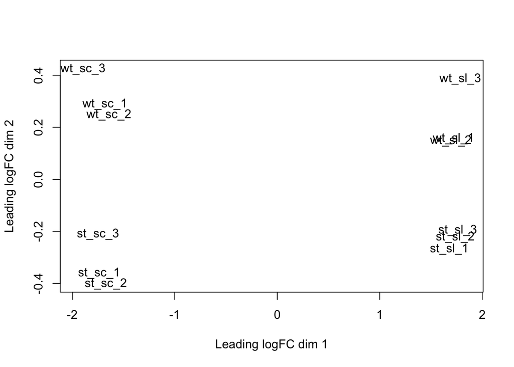

```r
#Podemos visualizar la dispersión de nuestras librerías usando el plot MDS

plotMDS(dge)
```

##Ejercicio ####¿Están bien las réplicas biológicas?

Para poder hacer el análisis de expresión diferencial, es necesario normalizar nuestros datos, para esto edgeR nos permite calcular un factor de normalización.

```r
dgeNorm = calcNormFactors(dge)

#Puedes visualizar los factores de normalización
dgeNorm$samples
```

```
##         group lib.size norm.factors
## wt_sc_1 wt_sc  9934217    0.9523396
## wt_sc_2 wt_sc 12547058    0.9827551
## wt_sc_3 wt_sc 11625013    0.9533961
## st_sc_1 st_sc 12644400    0.9461033
## st_sc_2 st_sc 12841546    0.9380211
## st_sc_3 st_sc 12129716    0.9446216
## wt_sl_1 wt_sl 11905547    1.0384549
## wt_sl_2 wt_sl 14069935    1.0333695
## wt_sl_3 wt_sl 10551580    1.0745259
## st_sl_1 st_sl 12621788    1.0427334
## st_sl_2 st_sl 13191822    1.0292570
## st_sl_3 st_sl 14015173    1.0802472
```

## Relizando el análisis de expresión diferencial

```r
#estimaremos la dispersión entre nuestras librerías
dgeNorm = estimateCommonDisp(dgeNorm)

#podemos visualizar este valor (si no tuvieran replicas es posible ingresar este valor manualmente, pero no es ideal)
dgeNorm$common.dispersion
```

```
## [1] 0.01244444
```

```r
#Calculando la expresión diferencial entre nuestras librerias (prueba pareada, exact-test)

#Pueden especificar que grupo de datos desean comparar
diff_exp = exactTest(dgeNorm, dispersion = dgeNorm$common.dispersion, pair = c("wt_sc", "wt_sl" ))
diff_exp2 = exactTest(dgeNorm, dispersion = dgeNorm$common.dispersion, pair = c("st_sc", "st_sl" ))

#ahora visualizaremos el objeto resultante de la prueba exacta de Fisher (objeto DGEExact)

diff_exp
```

```
## An object of class "DGEExact"
## $table
##              logFC   logCPM       PValue
## YPR161C -0.2667578 6.699863 4.976840e-02
## YOL138C  1.1041798 6.513021 1.270134e-15
## YDR395W -1.3861486 7.672860 2.325818e-24
## YGR129W -0.5085653 4.948519 4.809573e-04
## YPR165W -0.1687679 8.151630 2.051575e-01
## 5826 more rows ...
##
## $comparison
## [1] "wt_sc" "wt_sl"
##
## $genes
## NULL
```

```r
#si desean saber más sobre esta función
?exactTest

#podemos preguntar las dimenciones del objeto resultante
dim(diff_exp)
```

```
## [1] 5831    3
```

```r
#es deseable saber que genes tienen un mayor cambio y con que valor

topTags(diff_exp)
```

```
## Comparison of groups:  wt_sl-wt_sc
##            logFC    logCPM        PValue           FDR
## YGR087C 9.165529 10.695096  0.000000e+00  0.000000e+00
## YPL223C 8.613623 10.709007  0.000000e+00  0.000000e+00
## YLL057C 6.965209 10.326166  0.000000e+00  0.000000e+00
## YLR142W 6.825796  9.677000  0.000000e+00  0.000000e+00
## YKR039W 6.640134 11.207470  0.000000e+00  0.000000e+00
## YPL054W 6.634463  8.887542 7.082038e-311 6.882561e-308
## YBR072W 6.188202 11.519682 5.410924e-308 4.507299e-305
## YDR070C 7.062743  7.997711 2.803874e-306 2.043674e-303
## YHL016C 6.270902  9.741030 7.737170e-302 5.012827e-299
## YOR348C 6.654074  8.267520 1.451737e-295 8.465077e-293
```

```r
#podemos conocer cuantos genes nos esta arrojando el topTags

dim(topTags(diff_exp))
```

```
## [1] 10  4
```

```r
# guardar la tabla con todos los valores en un objeto de R y poder usarlo posteriormente es importante para nuestros fines.

deTab = topTags(diff_exp, n=Inf)$table

#esta tabla puede ser tratada con los comandos de selección y comparación que ya hemos visto

deTab[c(15,30),]
```

```
##             logFC    logCPM        PValue           FDR
## YGL147C -5.459016 10.037323 1.223899e-256 4.757705e-254
## YGR043C  5.114428  7.910794 2.206314e-211 4.288340e-209
```

```r
#podemos filtrar esta tabla por cualquier criterio matemático

row.names(deTab)[deTab$logFC > 5]  #recuerden que el FC esta dado en log2.
```

```
##  [1] "YGR087C" "YPL223C" "YLL057C" "YLR142W" "YKR039W" "YPL054W" "YBR072W"
##  [8] "YDR070C" "YHL016C" "YOR348C" "YNL142W" "YHR096C" "YLR327C" "YGR256W"
## [15] "YPL186C" "YJR152W" "YIR028W" "YBL075C" "YPL171C" "YFL014W" "YFL055W"
## [22] "YAL067C" "YDL169C" "YGR043C" "YGL184C" "YGR248W" "YDL210W" "YLR053C"
## [29] "YLR438W" "YNL117W" "YLR312C" "YIR017C" "YOL162W"
```

```r
#y podemos explorar los valores
deTab["YNL284C-A",]
```

```
##              logFC   logCPM       PValue          FDR
## YNL284C-A 1.810412 5.828709 1.387514e-31 7.908692e-31
```

```r
#esto nos permite entonces filtrar automáticamente por cualquier valor que predeterminemos
#aquí se proponen valores estándar de filtrado pero esto se puede modificar

deGenes = rownames(deTab)[deTab$FDR < 0.05 & abs(deTab$logFC) > 1]
down=row.names(deTab)[deTab$logFC< -1]
over=row.names(deTab)[deTab$logFC> 1]

#para saber el número total de genes que pasan estos filtros (genes diferenciales según nuestro criterio)

print(paste("total de diferenciales:", length(deGenes)))
```

```
## [1] "total de diferenciales: 2048"
```

```r
print(paste("número de genes inducidos:", length(over)))
```

```
## [1] "número de genes inducidos: 1050"
```

```r
print(paste("número de genes reprimidos:", length(down)))
```

```
## [1] "número de genes reprimidos: 998"
```

### Graficando los genes diferenciales para poder observar cómo se comportan y guardando los resultados

[figure not shown]

```r
plotSmear(dge, de.tags=deGenes, ylab = "WT-sc vs WT-sl")
```

```r
#Podemos exportar la tabla de genes diferenciales a nuestra carpeta de trabajo

write.table(deTab, file=paste(outpath, "diff_gene_wt.txt", sep=""), row.names=TRUE, col.names=NA, quote=FALSE, sep="\t")

#aquí exportamos solo los genes que se sobreexpresan o se reprimen.
write.table(down, file=paste(outpath, "down.txt", sep=""), row.names=TRUE, col.names=NA, quote=FALSE, sep="\t")
write.table(over, file=paste(outpath, "up.txt", sep=""), row.names=TRUE, col.names=NA, quote=FALSE, sep="\t")
```

## Gráficos de expresión diferencial

En esta sección les mostrare algunos de los gráficos con los que regularmente se presentan los resultados de los análisis que hemos realizado. Son básicos y ustedes pueden encontrar en la red ejemplos más sofisticados, todo depende de que quieran mostrar. Las paqueterías de R que usaremos serán gplots.

```r
#Instalando las paqueterias
#install.packages("gplots")
#install.packages("RcolorBrewer")


library("gplots")
library("RColorBrewer")
```

Visualizando nuestros datos de expresión diferencial en otro formato más interesante

```r
#normalizamos nuestros datos de expresión por cuentas por millón
normalizados= cpm(counts)

#extraemos la expresión de los genes diferenciales
normalizados_diferenciales= normalizados[deGenes,]

#veamos cómo se ve esta tablita
head(normalizados_diferenciales)
```

```
##           wt_sc_1   wt_sc_2   wt_sc_3   st_sc_1   st_sc_2   st_sc_3
## YGR087C  7.550449  6.615096  3.613450  4.429115  5.840769  8.738869
## YPL223C  9.562907  9.803095  7.311820  8.145899 11.057859 10.057943
## YLL057C 17.515220 20.403189 22.967717 17.003575 21.103378 24.567763
## YLR142W 12.985422 12.512893 14.967726 10.123059 14.017004 12.696092
## YKR039W 42.680766 47.341775 42.924685 49.666257 53.653977 68.262107
## YPL054W  8.958934 11.157994  8.602141 10.597577 10.279136 13.355630
##          wt_sl_1  wt_sl_2  wt_sl_3  st_sl_1   st_sl_2   st_sl_3
## YGR087C 3486.358 3544.153 4037.784 3143.849 3336.2337 3291.2188
## YPL223C 3747.413 4128.164 3486.397 3593.310 3402.4111 2614.7377
## YLL057C 2849.848 2671.015 2783.280 2112.854 3085.3207 2510.9216
## YLR142W 1803.445 1656.298 1540.148 1925.163 1619.4882 1665.0526
## YKR039W 4741.991 5057.237 4635.609 5208.850 4599.7438 5195.9403
## YPL054W 1035.652 1014.717 1066.760 1016.338  908.4416  842.9436
```

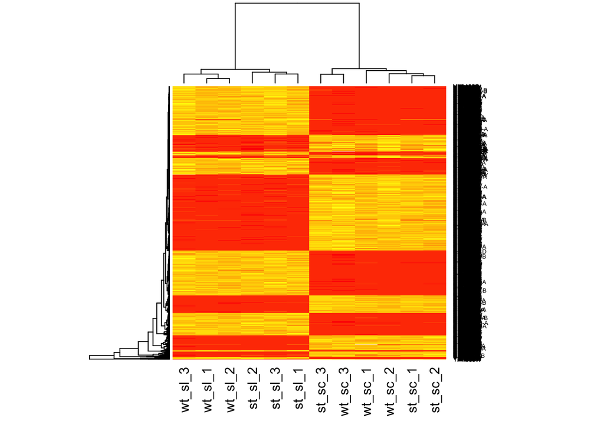

```r
#hagamos un HEATMAP!
heatmap(normalizados_diferenciales)
```

### Comparación de normalizados contra no-normalizados

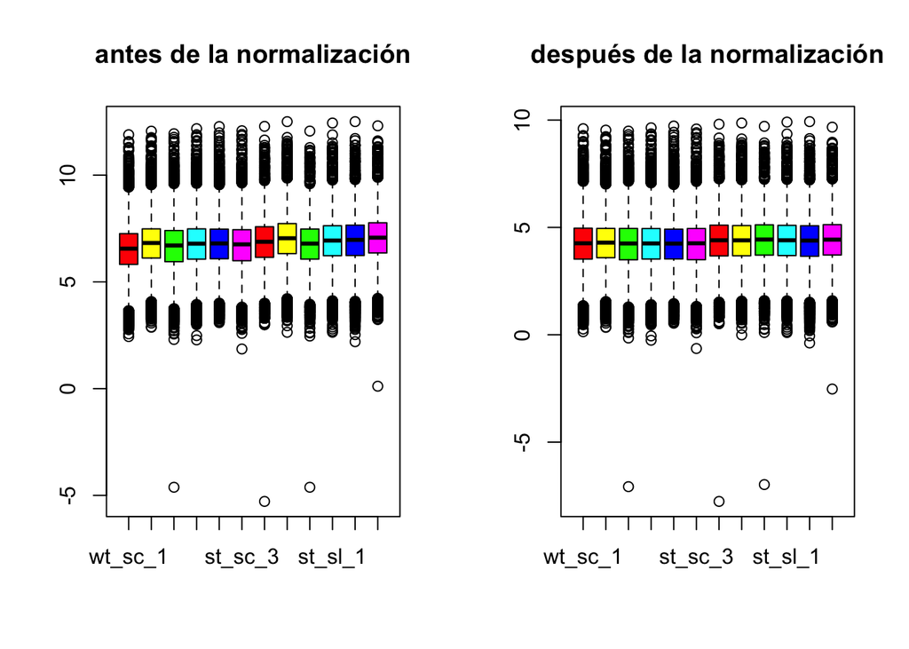

```r
par(mfrow=c(1,2))

boxplot(log(counts),col=rainbow(6), main="antes de la normalización")
boxplot(log(normalizados), col=rainbow(6), main="después de la normalización")
```

```r
#En estos gráficos vemos algunas alarmas, dado que tenemos algunos ceros que al ser convertidos por log2, se van al infinito.
```

### Barplot de la cantidad de reads en cada librería

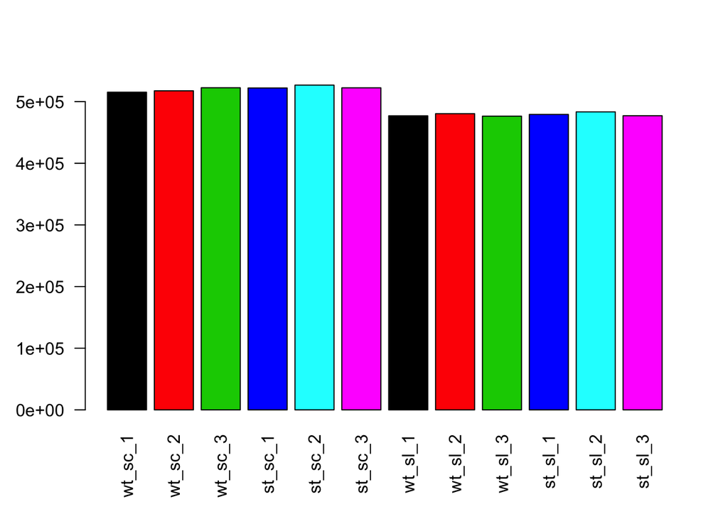

```r
barplot(apply(normalizados_diferenciales,2,sum),las=2, cex.names = 1, col = (1:6))
```

### Un PCA bonito de la distribución de nuestros datos

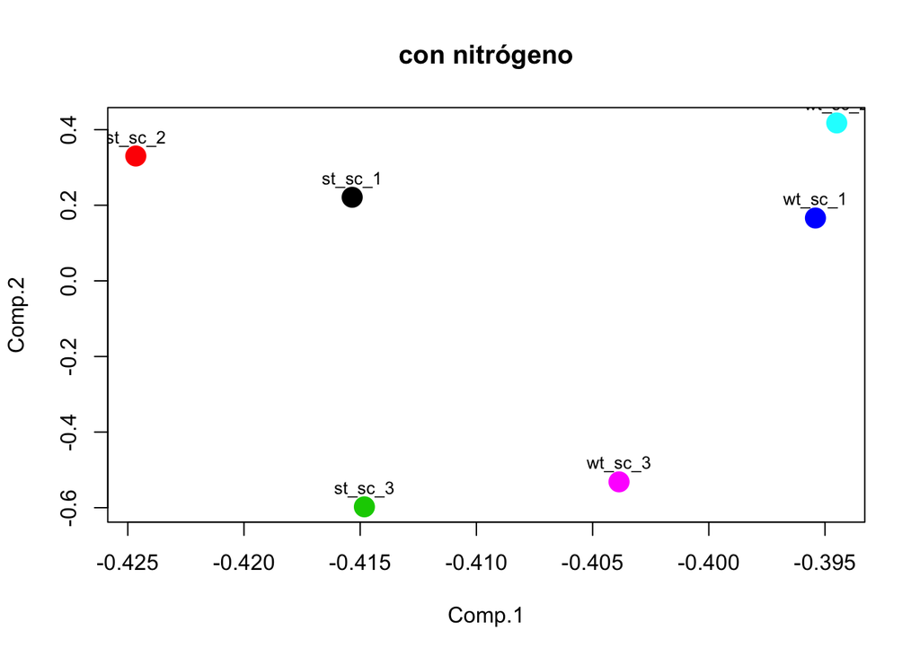

```r
pca <- princomp(normalizados_diferenciales[,c(1:6)])
plot(pca$loadings, col=as.factor(colnames(normalizados_diferenciales[,c(1:6)])),  pch=19, cex=2, main="con nitrógeno")
text(pca$loadings, as.vector(colnames(normalizados_diferenciales[,c(1:6)])), pos=3, cex=0.8)
```

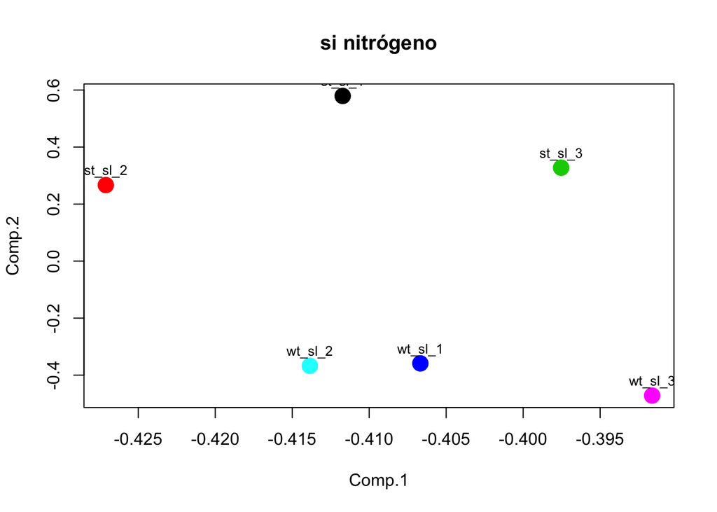

```r
pca <- princomp(normalizados_diferenciales[,c(7:12)])
plot(pca$loadings, col=as.factor(colnames(normalizados_diferenciales[,c(7:12)])),  pch=19, cex=2, main="si nitrógeno")
text(pca$loadings, as.vector(colnames(normalizados_diferenciales[,c(7:12)])), pos=3, cex=0.8)
```

### Hagamos unos bonitos volcano-plot, nos ayudaran a comparar los datos

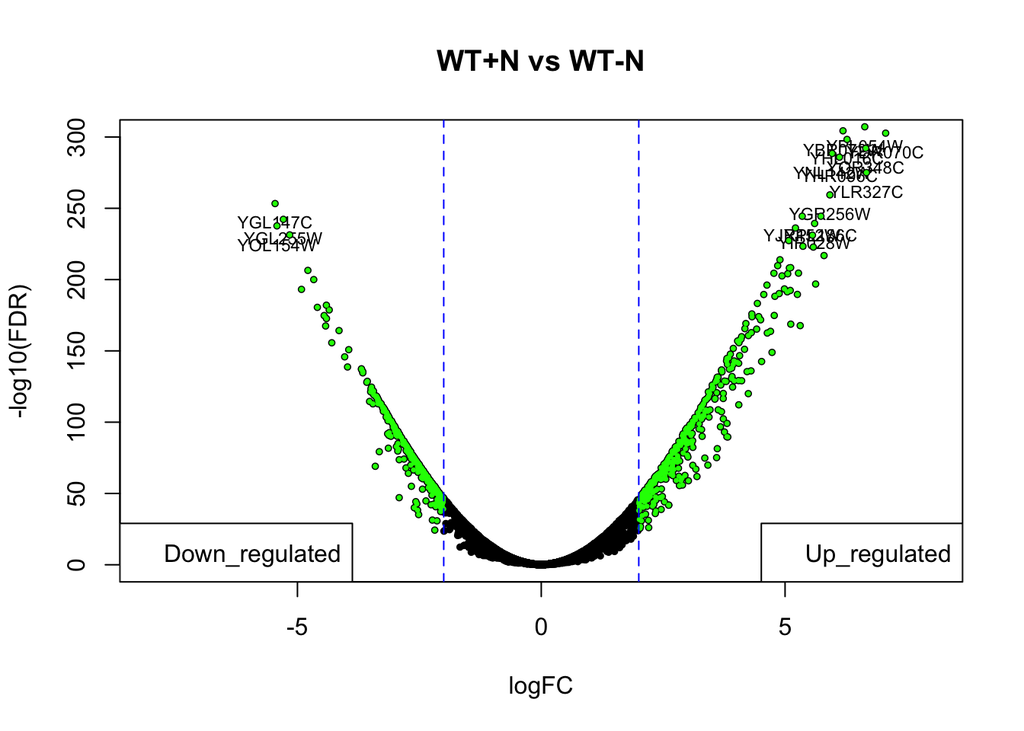

```r
with(deTab, plot(logFC, -log10(FDR), pch=20, cex=0.8, col="black", main="WT+N vs WT-N", xlim=c(-8, 8), ylim=c(0,300)))
text(deTab[1:20,]$logFC,-log(deTab[1:20,]$FDR,10),labels=rownames(deTab[1:20,]),cex=0.7,pos=1)
with(subset(deTab, FDR<.01 & abs(logFC)>2), points(logFC, -log10(FDR), pch=20, cex=0.5, col="green"))
abline(v=2,lty=2, col="blue")
abline(v=-2,lty=2, col="blue")
legend("bottomright","Up_regulated",cex=1)
legend("bottomleft","Down_regulated",cex=1)
```

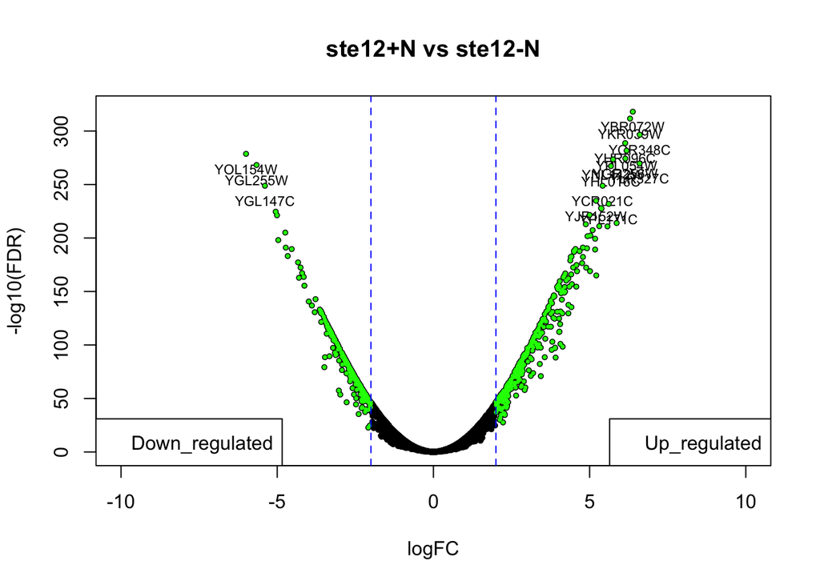

```r
deTab2 = topTags(diff_exp2, n=Inf)$table
deGenes2 = rownames(deTab2)[deTab2$FDR < 0.05 & abs(deTab2$logFC) > 1]


with(deTab2, plot(logFC, -log10(FDR), pch=20, cex=0.8, col="black", main="ste12+N vs ste12-N", xlim=c(-10, 10), ylim=c(0,320)))
text(deTab2[1:20,]$logFC,-log(deTab2[1:20,]$FDR,10),labels=rownames(deTab2[1:20,]),cex=0.7,pos=1)
with(subset(deTab2, FDR<.01 & abs(logFC)>2), points(logFC, -log10(FDR), pch=20, cex=0.5, col="green"))
abline(v=2,lty=2, col="blue")
abline(v=-2,lty=2, col="blue")
legend("bottomright","Up_regulated",cex=1)
legend("bottomleft","Down_regulated",cex=1)
```

Si desean saber qué genes no se comparten entre ambas cepas en los inducidos, podemos hacer lo siguiente

```r
WTover= head(rownames(deTab), 30)
ste12over= head(rownames(deTab2), 30)

setdiff(WTover, ste12over)
```

```
## [1] "YFL014W" "YAL067C" "YBR294W" "YGR043C"
```

#### Ahora veremos algunas herramientas en línea que nos pueden ayudar a darle más sentido a nuestro análisis:

##### https://genemania.org/

##### https://www.yeastgenome.org/cgi-bin/GO/goTermFinder.pl

# Súper!!!! ya saben hacer análisis de expresión diferencial